# Soil profile visualization · Visualización de perfiles de suelo

**Soil profile visualization** · Visualización de perfiles de suelo { ggplot2 } Carlos Guío 7/7/2021

## Happy soil conservation day!

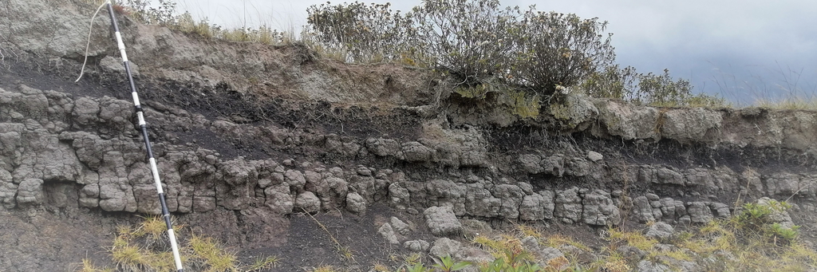

*A paleosol (buried and residual ancient soils) sequence in Cerro Seco, Bogotá.*

### Some context here · algo de contexto

I happen to be working on a conservation proposal for an area at the southern Bogotá boundary - known as Cerro Seco **(google it!** 😉) -, which has been afected by sand mining for decades. This is one of the few relicts of subxerophytic ecosystems in the region, and has been little studied -if at all 😤 - due to the socio-environmental conflicts there. We work in close collaboration with the local community through the stages of [data](https://github.com/cmguiob/TCI_CerroSeco_git/find/main) collection and management planning. *A key aspect here is communication: how to make soil (or paleosol in this case) data more accessible through visualization?* **Here I am sharing some tricks on how to plot visually appealing profiles using ggplot2. It will require some familiarity with the package. Let’s see the required data structure and packages first!**

Trabajo actuamente en una propuesta de conservación para un área en el sur de Bogotá - conocida como Cerro Seco -, la cuál ha sido explotada por décadas por la minería de arena. Es uno de los últimos relictos de ecosistémas subxerofíticos de la región y ha sido muy poco estudiado. Debido a acceso limitado, trabajamos en colaboración con la comunidad local para la recolección de [datos](https://github.com/cmguiob/TCI_CerroSeco_git/find/main) y la planeación del uso del terreno. *Un aspecto clave aquí es la comunicación: ¿cómo hacer los datos de suelo (o paleosuelos en este caso) mas accesibles a través de la visualización?.* **Aquí comparto algunos trucos para crear visualizaciones atractivas de perfiles usando ggplot2. Requiere algo del conocimiento de esta librería. Primero, veamos la estructura de los datos y las librerías requeridas!**

```r
horizons <- readr::read_csv('https://raw.githubusercontent.com/cmguiob/TCI_CerroSeco_git/main/Datos/Suelos_CS_Horiz.csv')

site <- readr::read_csv('https://raw.githubusercontent.com/cmguiob/TCI_CerroSeco_git/main/Datos/Suelos_CS_Sitio.csv')

#Select four profiles and relevant properties for plot
hz4 <- horizons %>%
  dplyr::filter(ID %in% c("CS01", "CS02","CS03","CS04")) %>%
  dplyr::select(ID, BASE, TOPE, ESP, HZ, CON_POR, MX_H, MX_V, MX_C, CON_H, CON_V, CON_C )

head(hz4, 10)
```

```
## # A tibble: 10 x 12
##    ID     BASE  TOPE   ESP HZ    CON_POR MX_H   MX_V  MX_C CON_H CON_V CON_C
##    <chr> <dbl> <dbl> <dbl> <chr>   <dbl> <chr> <dbl> <dbl> <chr> <dbl> <dbl>
##  1 CS01     35     0    35 A           0 10YR      4     2 2.5Y      5     8
##  2 CS01     80    35    45 E           2 10YR      5     1 2.5Y      5     8
##  3 CS01     90    80    10 Bt         80 10YR      4     1 10YR      2     1
##  4 CS01    140    90    50 B/C        10 10YR      5     1 10YR      2     1
##  5 CS01    170   140    30 Bn1         5 10YR      5     1 10YR      2     1
##  6 CS01    177   170     7 Bt1        80 2.5Y      4     1 10YR      2     1
##  7 CS01    250   177    73 C1          5 10YR      7     8 7.5YR     5     8
##  8 CS01    280   250    30 R           0 10YR      8     3 7.5YR     5     8
##  9 CS02     25     0    25 A           0 7.5YR     4     2 10YR      7     8
## 10 CS02     50    25    25 R           0 7.5YR     8     2 7.5YR     5     8
```

For the plot, the relevant variables are profile `ID`, depth of base and top of horizons (`BASE`, `TOPE`), horizon thickness (`ESP`), horizon name (`HZ`), percentage of concentrations (`CON_POR`), and Munsell color coordinates for the matrix and the concentrations (`MX_x`, `CON_x`).

Para la gráfica, las variables relevantes son `ID`del perfil, profundidad de la base y el tope (`BASE`, `TOPE`), espesor de lso horizontes (`ESP`), nomenclatura del horizonte (`HZ`), porcentaje de concetraciones (`CON_POR`), y colores Munsell de la matriz y concentraciones (`MX_x`, `CON_x`).

### A basic type of graph · un tipo de gráfica básico

Plotting soil profiles is not much different from plotting bar charts, but it takes some tinkering. If you are short of time, functions for plotting soil profiles - and other soil stuff - have been already incorporated in the `aqp` package by Dylan Beaudette, which has a nice [introduction](https://ncss-tech.github.io/AQP/aqp/aqp-intro.html).

So, why bother with ggplot2? Well, it has great compatibility among `geom_` family functions, which allow you to create complex plots with aesthetic freedom, it is well structured, extensively documented and transparent - great for debugging! -, and it can be easily incorporated in data workflows with `tidyverse` functions (**spoiler:** pipes `%>%` coming soon).

¿Por qué tomarse la molestia de usar ggplot2 para graficar perfiles, si ya existen funciones para esto? Por ejemplo la librería `aqp`, que tiene una genial [introducción](https://ncss-tech.github.io/AQP/aqp/aqp-intro.html) por Dylan Beadette. Pues, ggplot2 permite gran compatibilidad entre las funciones `geom_`, con lo cual tenemos libertad estética para crear gráficas complejas; es bien estructurado, detalladamente documentado y transparente - genial para depurar errores! - , y puede incorporarse fácilmente en los flujos de trabajo basados en `tidyverse` (**spoiler:** pipes `%>%` a continuación).

```r
# Create color variables | crear variables de color
hz4$RGBmx <- munsell2rgb(hz4$MX_H, hz4$MX_V, hz4$MX_C)
hz4$RGBco <-munsell2rgb(hz4$CON_H,hz4$CON_V , hz4$CON_C)


# Create factor variable with ID and HZ | Crear variable factor con ID y HZ
hz_bdf <- hz4 %>%
  dplyr::select(ID, BASE, TOPE, ESP,HZ, CON_POR, RGBmx, RGBco)%>%
  dplyr::mutate(ID_HZ = paste(ID, HZ),
         ID_HZ2 = factor(ID_HZ, ID_HZ))

head(hz_bdf, 5)
```

```
## # A tibble: 5 x 10
##   ID     BASE  TOPE   ESP HZ    CON_POR RGBmx     RGBco     ID_HZ    ID_HZ2
##   <chr> <dbl> <dbl> <dbl> <chr>   <dbl> <chr>     <chr>     <chr>    <fct>
## 1 CS01     35     0    35 A           0 #6F5F4CFF #9C750FFF CS01 A   CS01 A
## 2 CS01     80    35    45 E           2 #83796FFF #9C750FFF CS01 E   CS01 E
## 3 CS01     90    80    10 Bt         80 #686057FF #38302AFF CS01 Bt  CS01 Bt
## 4 CS01    140    90    50 B/C        10 #83796FFF #38302AFF CS01 B/C CS01 B/C
## 5 CS01    170   140    30 Bn1         5 #83796FFF #38302AFF CS01 Bn1 CS01 Bn1
```

We just transformed the Munsell colors to computer-readable colors (HEX) and stored them in the RGBmx and RGBco variables. The new factor variable `ID_HZ2` will be useful to assign fill colors in `geom_bar`. This is the function that we will tinker all the way down to the final plot.

Acabamos de transformar los colores Munsell a colores legibles por el computador (HEX) y los guardamos en las variables RGBmx y RGBco. La nueva variable tipo factor `ID_HZ2` será util para asignar los colores de relleno en `geom_bar`. Esta es la función que estaremos ajustando hasta el final.

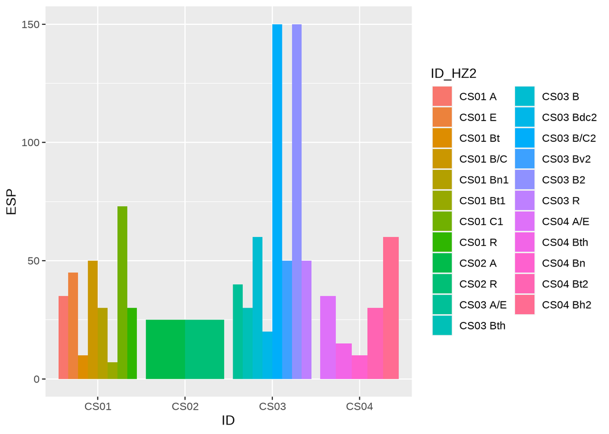

```r
ggplot(hz_bdf, aes(x = ID, y = ESP, fill = ID_HZ2)) +
  geom_bar(position="dodge", stat="identity")
```

This is the bar chart you are probably most familiar with. Here, each bar represents a horizon and the height its thickness.The bars are grouped by `ID`, we will keep it that way. You see the default colors are not very soil-like, we will change them next, along with a more useful arrangement of bars: the `stack`, as `position` argument.

Este es el diagrama de barras con el que probablemente tengas mas familiaridad. Aquí, cada barra representa un horizote y su altura representa el espesor. Las barras están agrupadas por `ID`, vamos a mantenerlas así. Como ves los colores por defecto no son de la “paleta de suelos”; vamos a cambiarla a continuación, junto con una configuración más útil de las barras: el `stack` (apilado), como argumento `position`.

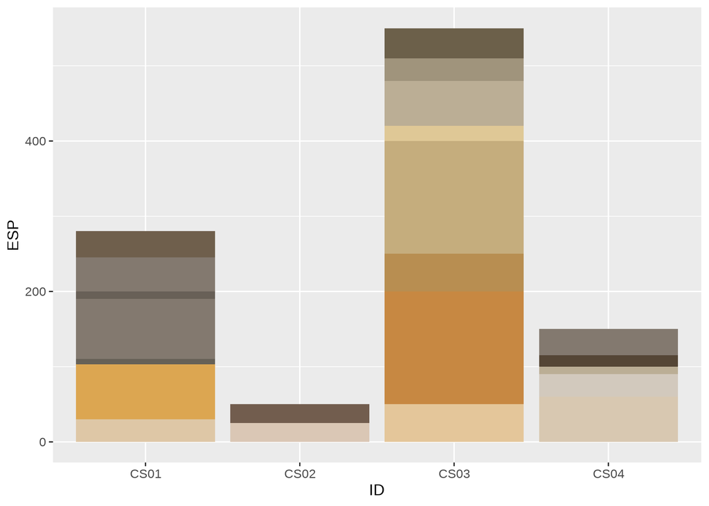

```r
profiles <- ggplot(hz_bdf, aes(x = ID, y = ESP, fill = ID_HZ2)) +
  geom_bar(position="stack", stat="identity") +
  # Adds colors from the RGBmx variable
  scale_fill_manual(values = hz_bdf$RGBmx,
                    # Don't plot the fill legend | no grafique leyenda de relleno
                    guide = "none")

profiles
```

Now they look pretty much as I remember them 😏. Though you might be wondering: what kind of horizons are those? And, aren’t soil profiles supposed to be dug from the top downwards? We will address these issues next, plus we will modify the bars’ width (**aesthetics tip**: make some space in your plot!).

Ahora se ven casi como los recuerdo. Sin embargo, quizás te preguntas por el tipo de horizontes y … ¿no se supone que los perfiles de suelo se cavan de la superficie hacia abajo?. Vamos a corregir esto, además de cambiar el ancho de las barras (**tip de estética**: crea algo de espacio!).

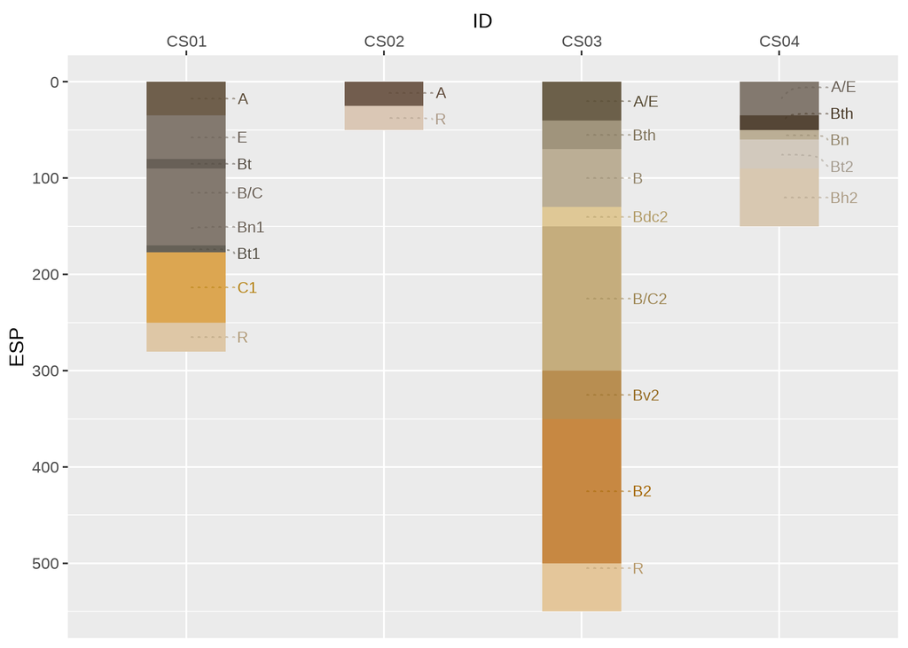

```r
profiles2 <- ggplot(hz_bdf,
                    aes(x = ID, y = ESP, fill = forcats::fct_rev(ID_HZ2))) +
  geom_bar(position="stack", stat="identity", width = 0.4) +
  # Adds colors from the RGBmx variable
  scale_fill_manual(values = rev(hz_bdf$RGBmx),
                    # Don't plot the fill legend | no grafique leyenda de relleno
                    guide = "none") +
  # Adds horizon labels | agrega etiquetas a horizontes
  ggrepel::geom_text_repel( data = hz_bdf,
                   aes(y = BASE - (ESP/2), label = HZ),
                   color = darken(hz_bdf$RGBmx, .2, space = "HCL"),
                   size = 3,
                   family = "robotoc",
                   hjust = 0,
                   direction = "y",
                   nudge_x = 0.3,
                   segment.size = .5,
                   segment.linetype = "dotted",
                   segment.square = TRUE,
                   segment.curvature = 0.1,
                   segment.angle = 30,
                   segment.alpha = 0.5,
                   box.padding = 0.3) +
  # Reverse y axis scale | Invierte la escala del eje y
  scale_y_reverse(breaks = c(0,100,200,300,400,500),
                  labels=c("0", "100", "200", "300", "400", "500"))+
  scale_x_discrete(position = "top")

profiles2
```

### Adding complexity · agregando complejidad

Still remember the dataset? There is a color variable that we haven´t used yet, the color of concentrations: these are *redox* or *illuvaition coatings*. We will create random points that represent these concentrations using the `CON_POR`: the percentage of concentrations in each horizon, and will encode them using `geom_jitter`.

Aún recuerdas los datos? Hay una variable de color que aún no hemos usado, el color de las concentraciones: estas son concentraciones tipo *redox* o *recubrimientos de iluviación*. Vamos a crear puntos aleatorios que representen estas concentraciones usando `CON_POR`: el porcentaje de concentraciones por horizonte, y las vamos a graficar usando `geom_jitter`.

```r
# New data frame with random points | Nuevo data frame con puntos aleatorios
hz_jdf <-  hz4 %>%
  dplyr::select(ID, BASE, TOPE, ESP,HZ, CON_POR, RGBmx, RGBco)%>%
  dplyr::mutate(ID = factor(ID),
         ID_HZ = paste(ID, HZ),
         ID_HZ2 = factor(ID_HZ, ID_HZ))%>%
  dplyr::mutate(CON_POR = ifelse(CON_POR == 0, 1, CON_POR),
         n = 5*ESP*CON_POR / 100,
         mean = 0.5*(BASE - TOPE),
         sd = 0.1*ESP)%>%
  dplyr::mutate(samples = purrr::pmap(.[11:13], rnorm))%>%
  tidyr::unnest(samples)

head(hz_jdf, 20)
```

```
## # A tibble: 20 x 14
##    ID     BASE  TOPE   ESP HZ    CON_POR RGBmx   RGBco  ID_HZ ID_HZ2     n  mean
##    <fct> <dbl> <dbl> <dbl> <chr>   <dbl> <chr>   <chr>  <chr> <fct>  <dbl> <dbl>
##  1 CS01     35     0    35 A           1 #6F5F4~ #9C75~ CS01~ CS01 A  1.75  17.5
##  2 CS01     80    35    45 E           2 #83796~ #9C75~ CS01~ CS01 E  4.5   22.5
##  3 CS01     80    35    45 E           2 #83796~ #9C75~ CS01~ CS01 E  4.5   22.5
##  4 CS01     80    35    45 E           2 #83796~ #9C75~ CS01~ CS01 E  4.5   22.5
##  5 CS01     80    35    45 E           2 #83796~ #9C75~ CS01~ CS01 E  4.5   22.5
##  6 CS01     90    80    10 Bt         80 #68605~ #3830~ CS01~ CS01 ~ 40      5
##  7 CS01     90    80    10 Bt         80 #68605~ #3830~ CS01~ CS01 ~ 40      5
##  8 CS01     90    80    10 Bt         80 #68605~ #3830~ CS01~ CS01 ~ 40      5
##  9 CS01     90    80    10 Bt         80 #68605~ #3830~ CS01~ CS01 ~ 40      5
## 10 CS01     90    80    10 Bt         80 #68605~ #3830~ CS01~ CS01 ~ 40      5
## 11 CS01     90    80    10 Bt         80 #68605~ #3830~ CS01~ CS01 ~ 40      5
## 12 CS01     90    80    10 Bt         80 #68605~ #3830~ CS01~ CS01 ~ 40      5
## 13 CS01     90    80    10 Bt         80 #68605~ #3830~ CS01~ CS01 ~ 40      5
## 14 CS01     90    80    10 Bt         80 #68605~ #3830~ CS01~ CS01 ~ 40      5
## 15 CS01     90    80    10 Bt         80 #68605~ #3830~ CS01~ CS01 ~ 40      5
## 16 CS01     90    80    10 Bt         80 #68605~ #3830~ CS01~ CS01 ~ 40      5
## 17 CS01     90    80    10 Bt         80 #68605~ #3830~ CS01~ CS01 ~ 40      5
## 18 CS01     90    80    10 Bt         80 #68605~ #3830~ CS01~ CS01 ~ 40      5
## 19 CS01     90    80    10 Bt         80 #68605~ #3830~ CS01~ CS01 ~ 40      5
## 20 CS01     90    80    10 Bt         80 #68605~ #3830~ CS01~ CS01 ~ 40      5
## # ... with 2 more variables: sd <dbl>, samples <dbl>
```

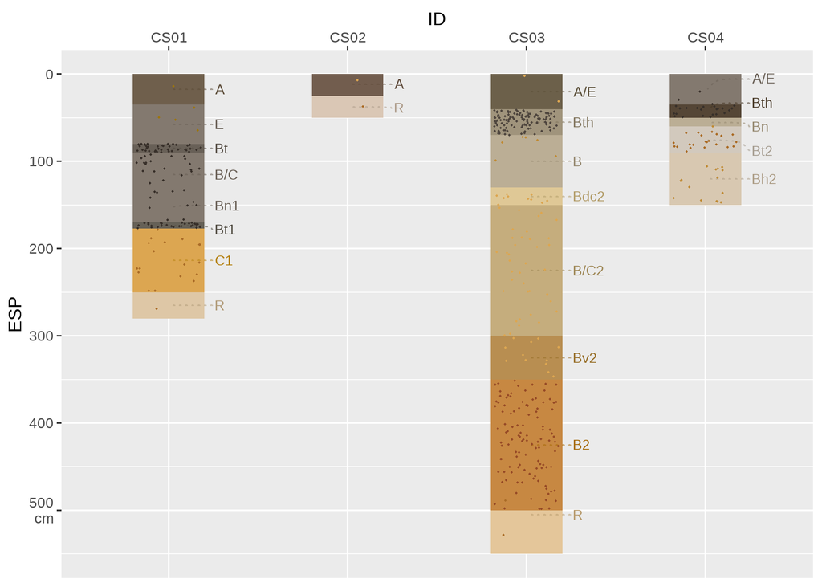

```r
profiles3 <- profiles2 +
#location from where jitter spreads out vertically
  geom_jitter(data = hz_jdf, aes(x = ID, y = BASE - (ESP/2)),
              width = 0.18,
              # how far jitter spreads out to each side
              height = hz_jdf$ESP*0.5,
              size = 0.3,
              col = hz_jdf$RGBco,
              shape = 16)+
  scale_y_reverse(breaks = c(0,100,200,300,400,500),
                  labels=c("0", "100", "200", "300", "400", "500\ncm"))+
  scale_x_discrete(position = "top")

profiles3
```

What follows is related to my personal taste. After some adjustments of the `theme`, here is my final version. You could add some other elements to this simple plot, such as other properties, processes, location, etc. I find the vast possibilities of data-based design pretty exciting!

Lo que sigue tiene que ver con mis gustos personales. Luego de algunos ajustes de `theme`, esta es mi versión final. A esta visualización simple se pueden agregar elementos que representen otras propiedades, procesos, localización, etc. Las varias posibilidades del diseño basado en datos son emocionantes!

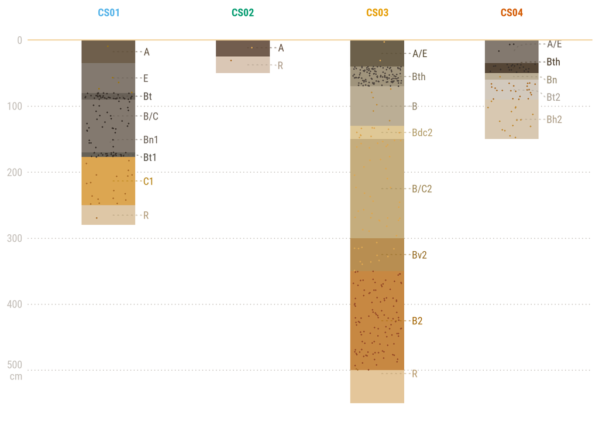